# p8105_hw1_yz4990

Yucheng Zhao

2024-09-21

## Problem 1

```r
library("palmerpenguins")
library("tidyverse")
```

**Load the dataset “penguins,” rename it to “penguins_df,” and clean the column names.**

```r
data("penguins", package = "palmerpenguins")
penguins_df = penguins |>
  janitor::clean_names()
```

**Summarize the data and get the variable names and size of the dataset**

```r
var_names = names(penguins_df)
col_number = ncol(penguins_df)
row_number = nrow(penguins_df)

summary(penguins_df)
```

```
##       species          island    bill_length_mm  bill_depth_mm
##  Adelie   :152   Biscoe   :168   Min.   :32.10   Min.   :13.10
##  Chinstrap: 68   Dream    :124   1st Qu.:39.23   1st Qu.:15.60
##  Gentoo   :124   Torgersen: 52   Median :44.45   Median :17.30
##                                  Mean   :43.92   Mean   :17.15
##                                  3rd Qu.:48.50   3rd Qu.:18.70
##                                  Max.   :59.60   Max.   :21.50
##                                  NA's   :2       NA's   :2
##  flipper_length_mm  body_mass_g       sex           year
##  Min.   :172.0     Min.   :2700   female:165   Min.   :2007
##  1st Qu.:190.0     1st Qu.:3550   male  :168   1st Qu.:2007
##  Median :197.0     Median :4050   NA's  : 11   Median :2008
##  Mean   :200.9     Mean   :4202                Mean   :2008
##  3rd Qu.:213.0     3rd Qu.:4750                3rd Qu.:2009
##  Max.   :231.0     Max.   :6300                Max.   :2009
##  NA's   :2         NA's   :2
```

**Delete rows with NA values, get mean flipper length**

```r
penguins_df = drop_na(penguins_df)

unique_species = unique(penguins_df[["species"]])
unique_island = unique(penguins_df[["island"]])
unique_sex = unique(penguins_df[["sex"]])
unique_year = unique(penguins_df[["year"]])

fl_mean = mean(penguins_df[["flipper_length_mm"]])
```

Here is a short description of the penguins dataset and its variables:

1. species: The species of penguins in the dataset. There are 3 unique species, which are Adelie, Gentoo, Chinstrap.
2. island: Islands that the penguins are from. There are 3 unique islands, which are Torgersen, Biscoe, Dream.
3. bill_length_mm: Bill length of penguins in mm. The range of this variable is [32.1, 59.6].
4. flipper_length_mm: Flipper length of penguins in mm. The range of this variable is [172, 231].
5. body_mass_g: Body mass of the penguins in g. The range of this variable is [2700, 6300].
6. sex: Sex of the penguins. There are 2 sex among the penguins, being male, female.
7. year: Years when the data is collected. The data are collected in 3 years, including 2007, 2008, 2009.

The dataset has 8 variables, which are: species, island, bill_length_mm, bill_depth_mm, flipper_length_mm, body_mass_g, sex, year. The size of the data consists of 8 columns and 344 rows. The rows with ‘NA’ values are removed latter.

The mean flipper length of the penguins is 200.966967mm.

**Check the first six rows of the dataset.**

```r
head(penguins_df)
```

```
## # A tibble: 6 × 8
##   species island    bill_length_mm bill_depth_mm flipper_length_mm body_mass_g
##   <fct>   <fct>              <dbl>         <dbl>             <int>       <int>
## 1 Adelie  Torgersen           39.1          18.7               181        3750
## 2 Adelie  Torgersen           39.5          17.4               186        3800
## 3 Adelie  Torgersen           40.3          18                 195        3250
## 4 Adelie  Torgersen           36.7          19.3               193        3450
## 5 Adelie  Torgersen           39.3          20.6               190        3650
## 6 Adelie  Torgersen           38.9          17.8               181        3625
## # ℹ 2 more variables: sex <fct>, year <int>
```

**Make and save the scatter plot.**

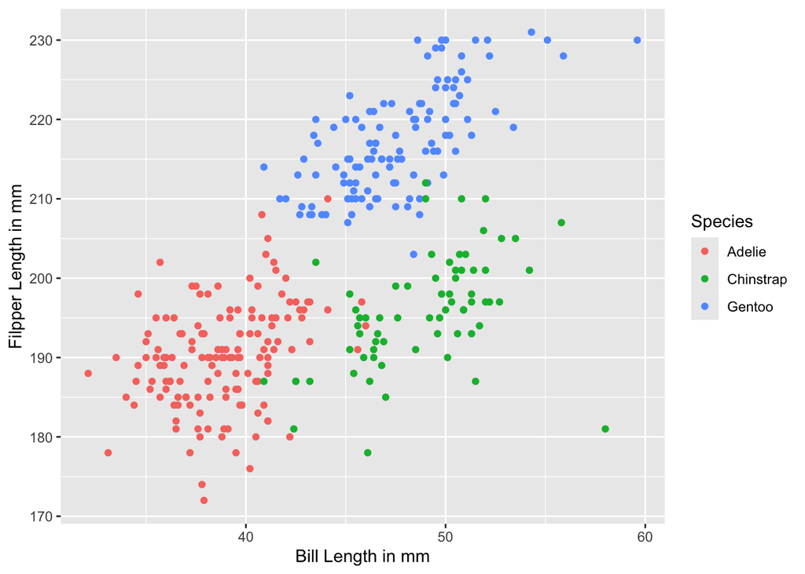

```r
ggplot(penguins_df, aes(x = bill_length_mm, y = flipper_length_mm)) +
  geom_point(aes(color = factor(species))) +
  labs(x = "Bill Length in mm", y = "Filpper Length in mm", color = "Species")
```

```r
ggsave("scatter_plot.pdf", height = 4, width = 6)
```

## Problem 2

**Create the data frame**

```r
p2_df = tibble(
  vec_rand = rnorm(10),
  vec_logi = vec_rand > 0,
  vec_char = c("a", "b", "c", "abc", "d", "e", "f", "def", "g", "h"),
  vec_fact = factor(c("bad", "bad", "bad", "average", "average", "average", "good", "good", "good", "good"))
)
mean(pull(p2_df, vec_rand))
```

```
## [1] -0.1692288
```

```r
mean(pull(p2_df, vec_logi))
```

```
## [1] 0.4
```

```r
mean(pull(p2_df, vec_char))
```

```
## [1] NA
```

```r
mean(pull(p2_df, vec_fact))
```

```
## [1] NA
```

**Change the non-numeric vectors to numeric, not showing the result**

```r
as.numeric(pull(p2_df, vec_logi))
as.numeric(pull(p2_df, vec_char))
as.numeric(pull(p2_df, vec_fact))
```

- The logic vector becomes 0, 0, 0, 1, 0, 0, 0, 1, 1, 1 after changing to numeric because r converts ‘FALSE’ to 0 and ‘TRUE’ to 1. This explains why the mean of the logic vecotor is 0.4.
- The character vector becomes NA, NA, NA, NA, NA, NA, NA, NA, NA, NA after changing to numeric because as.numeric() will return NA’s for characters as they do not have a numeric meaning. This explains why the mean of the character vector is NA.
- The factor vector also becomes 2, 2, 2, 1, 1, 1, 3, 3, 3, 3 after changing to numeric because the level of the factors are converted to 1, 2, and 3 as there are 3 factors. When trying to take the mean, r returns NA because the mean() function can not be implied to factor vectors directly before converting to numeric.